# CMPS_Project_Milestone_2_Thomas_Swide_Final_Submission

Thomas Swide - Milestone 2 thomasswide.github.io

## Download Project Datasets below

**World Inequality Data:**  
[Download WID Data](https://drive.google.com/uc?export=download&id=1w9bfo3tqwVcLmdakqUALSt8hk-A_kKDr)

**Maddison Project Database:**  
[Download Maddison Data](https://drive.google.com/uc?export=download&id=1IjsxFDUaPALLi9MbwcGb1ckdY6UEkqaj)

**Penn World Tables:**  
[Download PWT Data](https://drive.google.com/uc?export=download&id=1hfNUYkeuIRmOM-vGaixsPiy9dOZ7SXgY)

### Project Goals

While initially I’d planned to look at economic growth somewhat widely, I’ve chosen to specify the goal of my project to better understand the dynamics of economic growth and inequality throughout the course of history, hopefully allowing me to make some predictions and theorize on the potential impact of future policy decisions.

### Collaboration Plan

As a graduate student I will be working alone, but plan on leveraging all resources made available to me both on campus and off to ensure that I am staying on track, getting the advice and assistance I need, and achieving the goal of this project.

### Project Dataset

I will be using three datasets, the Penn World Tables 11.0 dataset found [here](https://www.rug.nl/ggdc/productivity/pwt/?lang=en), the Maddison Project Database update from 2020 found [here](https://www.rug.nl/ggdc/historicaldevelopment/maddison/releases/maddison-project-database-2020?lang=en), and the World Inequality database found [here](https://wid.world/data/), most recently updated in 2023. The Penn World Tables (PWT) data provides information on relative levels of income, output, input and productivity, covering 185 countries between 1950 and 2023. The Maddison Project data provides historical estimates of real GDP and population for countries extending back as far as the year 1 CE, allowing me to gain an expanded view into economic development historically. Its consistent cross-country methodology makes it possible to compare growth trajectories across major economies and identify structural transitions such as industrialization, postwar recovery, and long-run convergence or divergence. Crucially it supplies the essential long-run GDP per capita series needed to analyze how growth patterns evolve alongside changes in inequality. Lastly, I will be adding in the World Inequality Database’s (WID) most recent update from 2023. The WID data provides detailed, internationally comparable measures of income and wealth distribution, built from tax records, national accounts, and household surveys. It offers a variety of inequality indicators—including top income shares and bottom-50% shares— that allow meaningful comparisons across countries and over time. This dataset will provide the essential inequality series needed to study how shifts in income distribution relate to long-run economic growth.

### ETL (Extraction, Transform, and Load)

I have loaded all 3 of my datasets. First, I extracted the raw inequality data from the World Inequality Database, keeping only the variables that represent true income shares. I then transformed the data by mapping percentile codes to more meaningful labels, reshaping it into a country–year table, converting fractions to percentages, and creating additional variables for the Top 10% Share, Top 10–1% share, Bottom 50% share, and Top 1% share. Next, I loaded the Maddison Project and Penn World Table datasets, cleaned their year and GDP variables, and computed long-run growth measures like log growth and 10-year rolling average growth. Finally, I merged all three cleaned datasets—WID, MPD, and PWT—into a single file organized by country and year. The result is a fully cleaned and merged dataset that combines long-run growth, modern macroeconomic indicators, and inequality measures, and should enable me to gain insight into some of the trends I will begin to unpack below.

```python
import pandas as pd
import numpy as np
import os

# Load WID file to clean inequality variables
wid = pd.read_csv("/content/drive/MyDrive/CMPS Project Data/df_WID_merged.csv")

# Keep only the relevant WID variable
wid_shares = wid[wid["variable"] == "sptincj999"].copy()

# Map percentiles to actual income-share concepts
perc_map = {
    "p99p100": "top1_share",
    "p90p100": "top10_share",
    "p0p50":   "bottom50_share"
}

wid_shares = wid_shares[wid_shares["percentile"].isin(perc_map.keys())]
wid_shares["series"] = wid_shares["percentile"].map(perc_map)

# Pivot
wid_clean = wid_shares.pivot_table(
    index=["country", "year"],
    columns="series",
    values="value"
).reset_index()

# Convert fractions to percentages
for col in ["top1_share", "top10_share", "bottom50_share"]:
    wid_clean[col] = wid_clean[col] * 100

# Create top 10–1% share
wid_clean["top10_1_share"] = wid_clean["top10_share"] - wid_clean["top1_share"]

# Sort and save
wid_clean = wid_clean.sort_values(["country", "year"])
wid_clean.to_csv("/content/drive/MyDrive/CMPS Project Data/wid_clean_inequality.csv", index=False)

print(wid_clean.head())
print(wid_clean.describe())
```

```
series country  year  bottom50_share  top10_share  top1_share  top10_1_share
0       France  1820           14.83        50.90       19.70          31.20
1       France  1850           14.60        51.68       20.80          30.88
2       France  1880           14.53        51.89       21.50          30.39
3       France  1900           16.30        49.42       23.69          25.73
4       France  1910           14.55        51.84       22.73          29.11
series         year  bottom50_share  top10_share  top1_share  top10_1_share
count    395.000000      395.000000   395.000000  395.000000     395.000000
mean    1972.346835       18.725468    38.427519   13.734861      24.692658
std       40.819943        2.951282     6.229292    4.350316       2.925359
min     1820.000000       12.950000    27.360000    6.940000      18.360000
25%     1946.000000       16.470000    33.945000   10.455000      22.605000
50%     1984.000000       19.220000    36.670000   12.590000      24.150000
75%     2004.000000       20.645000    43.365000   16.770000      26.255000
max     2023.000000       25.130000    55.060000   27.600000      33.270000
```

```python
# Load datasets to merge
mpd = pd.read_csv("/content/drive/MyDrive/CMPS Project Data/mpd2020.csv")
pwt = pd.read_csv("/content/drive/MyDrive/CMPS Project Data/pwt110.csv")
wid = pd.read_csv("/content/drive/MyDrive/CMPS Project Data/wid_clean_inequality.csv")

# Keep only core countries
countries = ["United States", "United Kingdom", "France", "Germany", "Japan"]

mpd = mpd[mpd["country"].isin(countries)].copy()
pwt = pwt[pwt["country"].isin(countries)].copy()
wid = wid[wid["country"].isin(countries)].copy()

# Clean MPD (Maddison) and compute growth terms
mpd["year"] = pd.to_numeric(mpd["year"], errors="coerce")

# Clean gdppc (remove commas, convert to float)
mpd["gdppc"] = (
    mpd["gdppc"]
    .astype(str)
    .str.replace(",", "", regex=False)
)

mpd["gdppc"] = pd.to_numeric(mpd["gdppc"], errors="coerce")

# Compute log GDP per capita growth (year-over-year, %)
mpd["g_gdppc"] = (
    mpd.groupby("country")["gdppc"]
       .transform(lambda x: 100 * np.log(x).diff())
)

# Compute 10-year rolling growth
mpd["g10"] = (
    mpd.groupby("country")["g_gdppc"]
       .transform(lambda x: x.rolling(10, min_periods=1).mean())
)

# Clean PWT
pwt["year"] = pd.to_numeric(pwt["year"], errors="coerce")

# Clean WID inequality data
wid["year"] = pd.to_numeric(wid["year"], errors="coerce")

# Merge: MPD + WID
combined = mpd.merge(
    wid,
    on=["country", "year"],
    how="left"
)

# Merge: + PWT
combined = combined.merge(
    pwt,
    on=["country", "year"],
    how="left",
    suffixes=("", "_pwt")
)

# Save cleaned merged dataset
output_dir = "/content/drive/MyDrive/CMPS Project Data/data_clean"
os.makedirs(output_dir, exist_ok=True)

output_path = os.path.join(output_dir, "combined_data.csv")
combined.to_csv(output_path, index=False)

print("\n-----------------------------------------")
print(" CLEAN MERGE COMPLETE ")
print("-----------------------------------------")
print("Saved to:", output_path)
print("Shape:", combined.shape)
print("\nColumns:")
print(combined.columns.tolist())
```

```
-----------------------------------------
 CLEAN MERGE COMPLETE
-----------------------------------------
Saved to: /content/drive/MyDrive/CMPS Project Data/data_clean/combined_data.csv
Shape: (2126, 60)

Columns:
['countrycode', 'country', 'year', 'gdppc', 'pop', 'g_gdppc', 'g10', 'bottom50_share', 'top10_share', 'top1_share', 'top10_1_share', 'countrycode_pwt', 'currency_unit', 'rgdpe', 'rgdpo', 'pop_pwt', 'emp', 'avh', 'hc', 'ccon', 'cda', 'cgdpe', 'cgdpo', 'cn', 'ck', 'ctfp', 'cwtfp', 'rgdpna', 'rconna', …
```

### Trends in Income Share by Percentile

I am going to start by filtering my data to only include a few priority countries, the US, UK, France, Germany, and Japan. There are a few reasons for this, mainly that these countries have more reliable and extensive figures, and also because these countries represent a sample of highly connected economies. While arguments could be made that there are other countries that could be included, in my research I feel that these will provide valuable insights. As a note on the data, France and the US have excellent historical data going back to the beginning of the 20th Century due largely to an interrupted chain of government and tax records, while the data for the UK, Japan, and Germany, specifically the inequality microdata, is frequently either unavailable or unreliable prior to roughly 1980 due to a number of factors, mostly poor surveying and war-related losses in archives. With these countries selected, I am going to begin to visualize the trends in income shares among the different percentiles (Top 1%, Top 10%, Top 1-10%, Bottom 50%). I am choosing to leave all 5 countries in because I think their related trends are worth seeing post 1980, but as will be seen in the plots France and US will provide the most valuable insight given that their tax records stretch back about 70 years further.

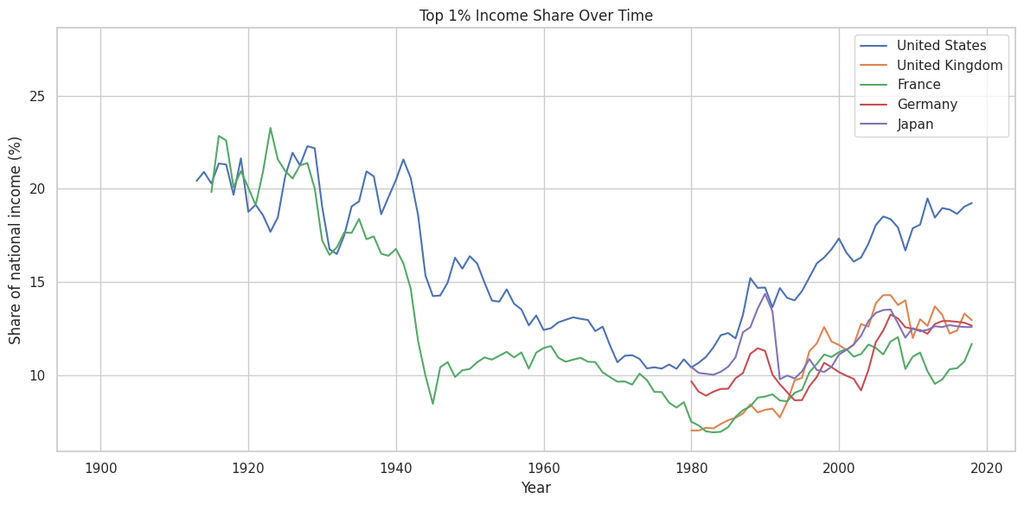

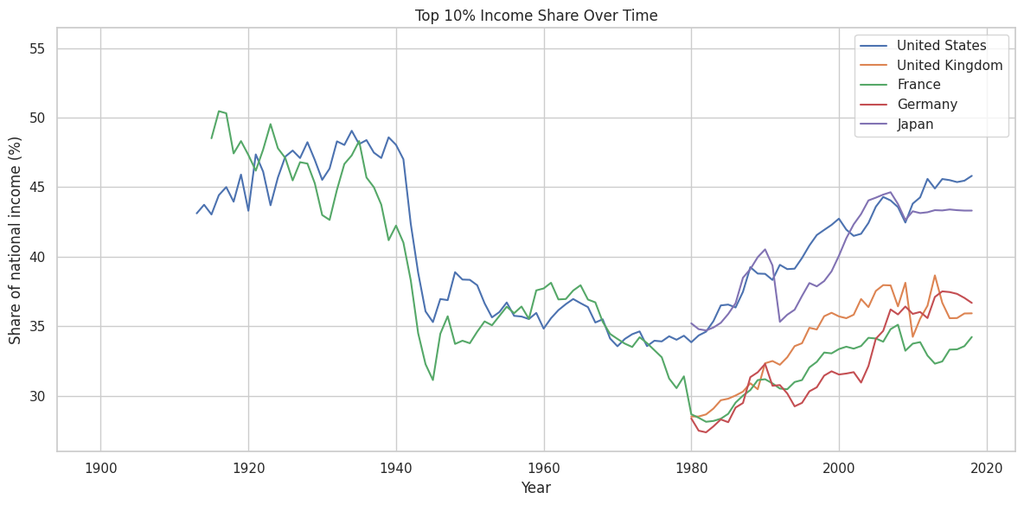

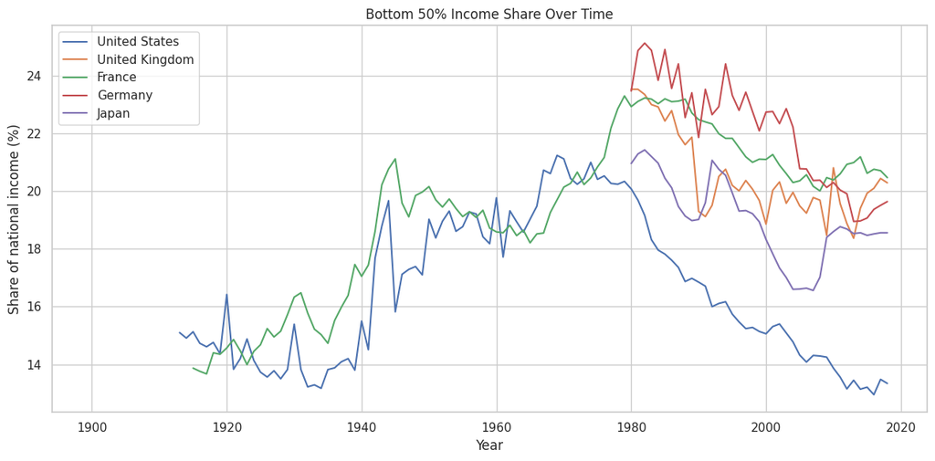

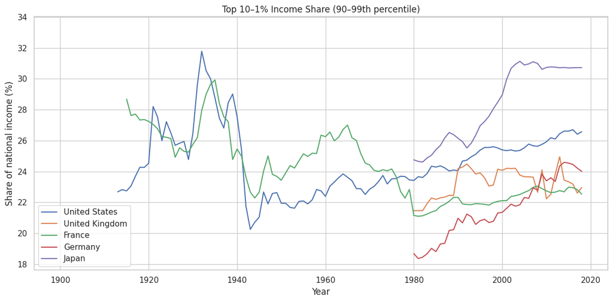

```python
import matplotlib.pyplot as plt
import seaborn as sns

sns.set_theme(style="whitegrid")

df = pd.read_csv("/content/drive/MyDrive/CMPS Project Data/data_clean/combined_data.csv")

countries = ["United States", "United Kingdom", "France", "Germany", "Japan"]
df = df[df["country"].isin(countries)].copy()

df["year"] = pd.to_numeric(df["year"], errors="coerce")
df = df[df["year"] >= 1900].copy()

for col in ["top1_share", "top10_share", "bottom50_share", "top10_1_share"]:
    if col in df.columns:
        df[col] = pd.to_numeric(df[col], errors="coerce")

def ts_plot(col, title, ylabel):
    if col not in df.columns:
        print(f"Column '{col}' not found – skipping.")
        return
    plt.figure(figsize=(12, 6))
    for c in countries:
        temp = df[df["country"] == c]
        plt.plot(temp["year"], temp[col], label=c)
    plt.title(title)
    plt.xlabel("Year")
    plt.ylabel(ylabel)
    plt.legend()
    plt.tight_layout()
    plt.show()

ts_plot("top1_share", "Top 1% Income Share Over Time", "Share of national income (%)")
ts_plot("top10_share", "Top 10% Income Share Over Time", "Share of national income (%)")
ts_plot("bottom50_share", "Bottom 50% Income Share Over Time", "Share of national income (%)")
ts_plot("top10_1_share", "Top 10–1% Income Share (90–99th percentile)", "Share of national income (%)")
```

### Trends in GDP Growth

Below, I am going to look at historical GDP growth, using GDP per Capita for the selected countries and filtering to see the trend between 1820 and 2020. While the GDP information does reach back much further, it's reliability is certainly reasonable to question and it's relevance to modern trends less clear. For that reason I've limited the time series I'm visualizing to this 200 year period. Additionally, I want to look at a 10 year rolling average of GDP per Capita growth to see if there are any interesting trends or events that can be learned from there.

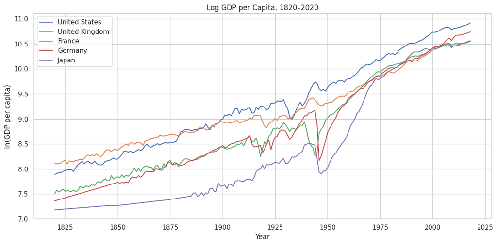

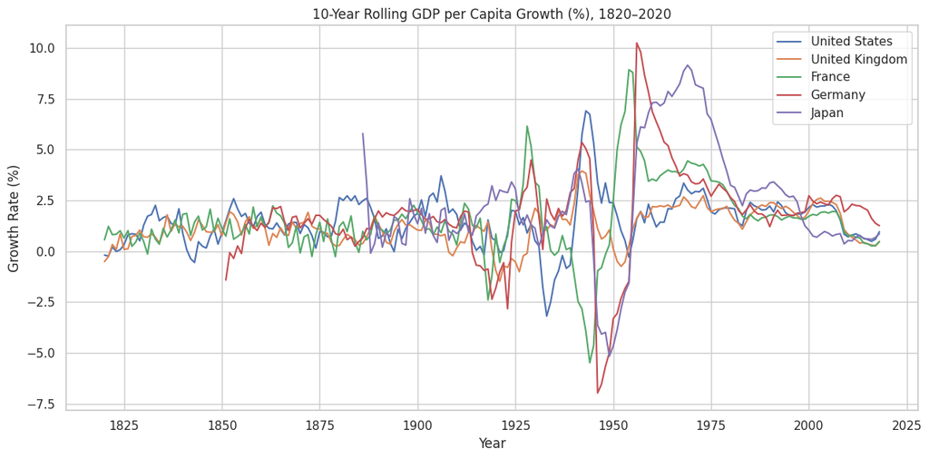

```python
sns.set_theme(style="whitegrid")
df = pd.read_csv("/content/drive/MyDrive/CMPS Project Data/data_clean/combined_data.csv")

countries = ["United States", "United Kingdom", "France", "Germany", "Japan"]
df = df[df["country"].isin(countries)].copy()

# Ensure numeric
df["year"] = pd.to_numeric(df["year"], errors="coerce")
df["gdppc"] = pd.to_numeric(df["gdppc"], errors="coerce")
df["g10"] = pd.to_numeric(df["g10"], errors="coerce")

# Restrict to 1820-2020, data less reliable outside of that window.
df = df[(df["year"] >= 1820) & (df["year"] <= 2020)]

# Ensure positive GDP for log
df = df[df["gdppc"] > 0]

df = df.sort_values(["country", "year"])

# Log GDP per Capita (1820–2020)
plt.figure(figsize=(12, 6))

for c in countries:
    temp = df[df["country"] == c]
    plt.plot(temp["year"], np.log(temp["gdppc"]), label=c)

plt.title("Log GDP per Capita, 1820–2020")
plt.xlabel("Year")
plt.ylabel("ln(GDP per capita)")
plt.legend()
plt.tight_layout()
plt.show()

# Long-Run Growth Rates (10-Year Rolling)
plt.figure(figsize=(12, 6))

for c in countries:
    temp = df[df["country"] == c]
    plt.plot(temp["year"], temp["g10"], label=c)

plt.title("10-Year Rolling GDP per Capita Growth (%), 1820–2020")
plt.xlabel("Year")
plt.ylabel("Growth Rate (%)")
plt.legend()
plt.tight_layout()
plt.show()
```

### Growth - Inequality Overlay

Now I'm going to overlay inequality and growth, to visualize there relationship and gain insight into any convergence, divergence, correlation, etc.This will also give me a chance to see if there are noteworthy differences even between this limited group of relatively wealthy and economically interconnected countries. Given that this will incorporate the inequality data, I'm restricting the timeline to begin in 1910 corresponding with the initial microdata I have from France.

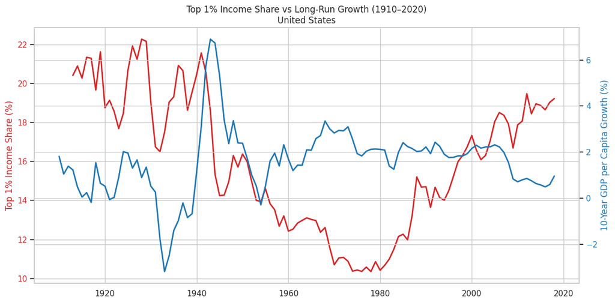

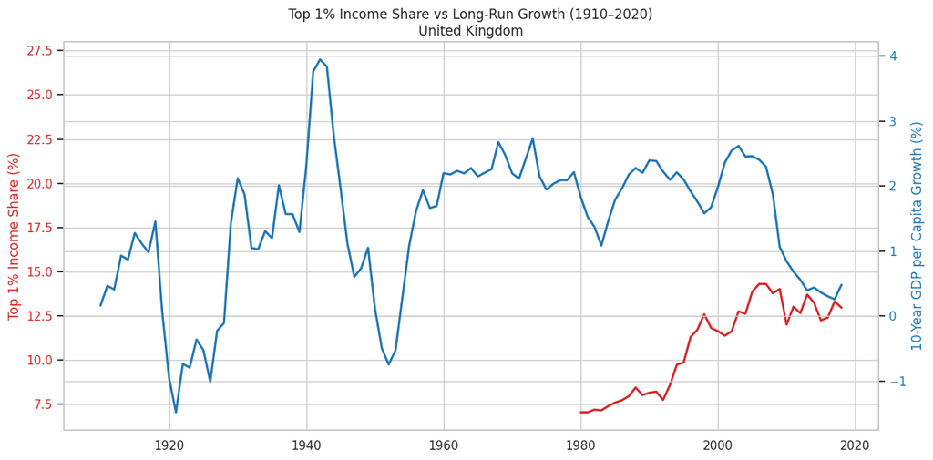

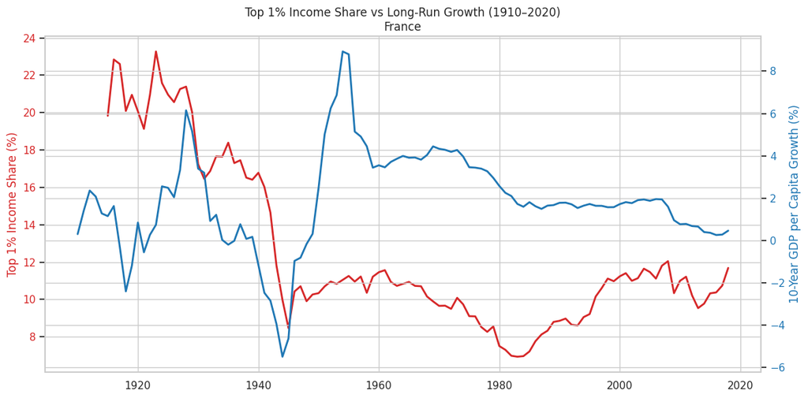

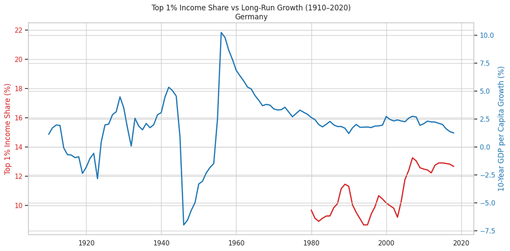

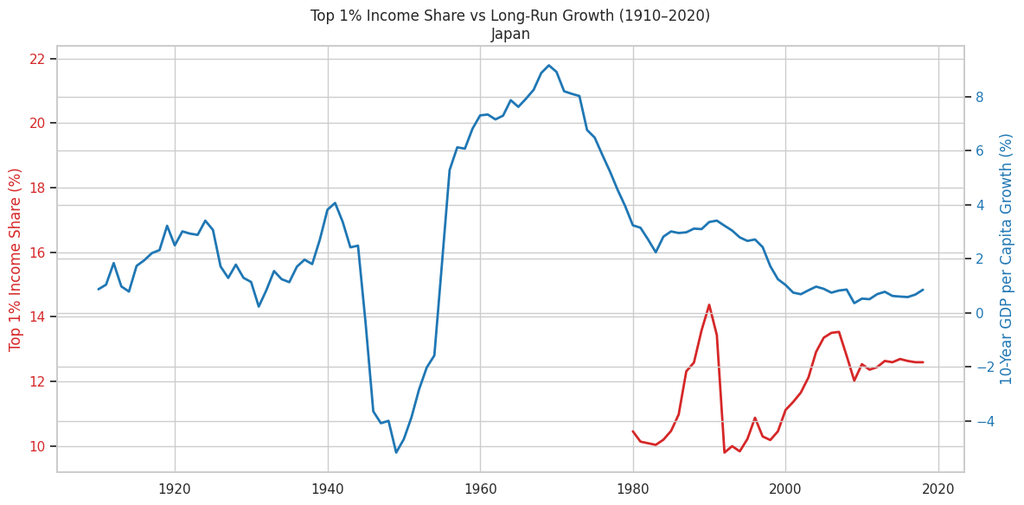

```python
sns.set_theme(style="whitegrid")
df = pd.read_csv("/content/drive/MyDrive/CMPS Project Data/data_clean/combined_data.csv")
countries = ["United States", "United Kingdom", "France", "Germany", "Japan"]

df = df[df["country"].isin(countries)].copy()

df["year"] = pd.to_numeric(df["year"], errors="coerce")
for col in ["top1_share", "bottom50_share", "g10"]:
    if col in df.columns:
        df[col] = pd.to_numeric(df[col], errors="coerce")

# Restrict to 1910–2020
df = df[(df["year"] >= 1910) & (df["year"] <= 2020)]
df = df.sort_values(["country", "year"])


# Two-axis overlay plot
def overlay_plot(country, ineq_col, title, ylabel_ineq):
    temp = df[df["country"] == country]

    fig, ax1 = plt.subplots(figsize=(12, 6))

    # Left axis — inequality
    color1 = "tab:red"
    ax1.set_ylabel(ylabel_ineq, color=color1)
    ax1.plot(temp["year"], temp[ineq_col], color=color1, linewidth=2)
    ax1.tick_params(axis="y", labelcolor=color1)

    # Right axis — growth
    ax2 = ax1.twinx()
    color2 = "tab:blue"
    ax2.set_ylabel("10-Year GDP per Capita Growth (%)", color=color2)
    ax2.plot(temp["year"], temp["g10"], color=color2, linewidth=2)
    ax2.tick_params(axis="y", labelcolor=color2)

    plt.title(f"{title}\n{country}")
    fig.tight_layout()
    plt.show()

# Top 1% Income Share vs Growth

for c in countries:
    overlay_plot(
        country=c,
        ineq_col="top1_share",
        title="Top 1% Income Share vs Long-Run Growth (1910–2020)",
        ylabel_ineq="Top 1% Income Share (%)"
    )
```

### Top 10% Income Share vs. 10-Year Rolling GDP per Capita Growth

Lastly for now, I'm going to make a scatterplot charting the Top 10% Income Share against 10-Year Rolling Average GDP per Capita Growth to see if there is a clearly visible correlation between the two. This could prove insightful in understanding how inequality and growth have historically related to on another. I'm including a regression line with 95% confidence interval to visualize their correlation.

[figure not shown]

```python
plt.figure(figsize=(12, 8))
sns.scatterplot(data=df_plot, x="g10", y="top10_share", hue="country", palette="tab10", alpha=0.7)
sns.regplot(data=df_plot, x="g10", y="top10_share", scatter=False, color="black", line_kws={'linestyle':'--','alpha':0.8}, label='Overall Regression Line')

plt.title("Overall Impact of Top 10% Income Share on 10-Year Rolling GDP per Capita Growth")
plt.xlabel("10-Year Rolling GDP per Capita Growth (%)")
plt.ylabel("Top 10% Income Share (%)")
plt.legend(title="Country")
plt.tight_layout()
plt.show()
```

### Closing Thoughts

My goal is to better understand the impact of inequality on economic growth or lack thereof. My hypothesis is that economic growth is negatively correlated with inequality, in other words that high inequality stagnates economic growth. With this historical data in hand, I can gain insights into their relationship over at least the past century and hopefully begin to theorize on the potential policy implications presented by that relationship. From what I've shown above, it appears that there is a relationship and that my hypothesis may hold true, but more analysis and consideration is needed.

```python
for root, dirs, files in os.walk("/content/drive/MyDrive", topdown=True):
    for f in files:
        if "CMPS" in f or "Swide" in f.lower():
            print(os.path.join(root, f))
```

```
/content/drive/MyDrive/CMPS PROJECT IDEAS.gdoc
/content/drive/MyDrive/Colab Notebooks/CMPS_Project_Milestone_2_Thomas_Swide_FinalSubmission.ipynb
/content/drive/MyDrive/Colab Notebooks/CMPS_Project_Milestone_2_Thomas_Swide.html
```

```python
!jupyter nbconvert --to html "/content/drive/MyDrive/Colab Notebooks/CMPS_Project_Milestone_2_Thomas_Swide_Final_Submission.ipynb"
```

```
[NbConvertApp] Converting notebook /content/drive/MyDrive/Colab Notebooks/CMPS_Project_Milestone_2_Thomas_Swide_Final_Submission.ipynb to html
[NbConvertApp] Writing 335031 bytes to /content/drive/MyDrive/Colab Notebooks/CMPS_Project_Milestone_2_Thomas_Swide_Final_Submission.html
```